# Adidas Sales Analysis-Copy1

**Adidas US Sales Analysis: Strategic Market Performance Review**

**Executive Summary**

**Business Problem**

Adidas US operations generated $899.9M in revenue across multiple product categories, regions, and sales channels. This analysis evaluates market performance to identify:

- High-performing and underperforming segments
- Margin efficiency opportunities
- Strategic resource allocation recommendations
- Revenue growth and optimization pathways

**Key Performance Indicators (Dataset Overview)**

[output not shown]

**Methodology**

*Data Processing*

- **Data Source**: Adidas US Sales Dataset (Excel format)
- **Records Analyzed**: 9,648 transaction records
- **Dimensions**: Product category, Region, City, Sales Method, Time
- **Cleaning Steps**:
  - Removed unnamed columns
  - Converted date fields to datetime
  - Standardized numeric formats
  - Validated data integrity

*Analytical Framework*

- **Descriptive Analytics**: Revenue, profit, and margin analysis by segment
- **Comparative Analysis**: Performance benchmarking across dimensions
- **Trend Analysis**: Time series decomposition and seasonality detection
- **Predictive Modeling**: Sales forecasting using statistical methods
- **Cluster Analysis**: Market segmentation and portfolio positioning
- **Statistical Testing**: Significance testing for regional/product differences

**Strategic Findings Summary**

1. **Product Performance**

[output not shown]

2. **Regional Performance**

[output not shown]

**Key Insight**: Coastal regions (West, Northeast) drive volume but face margin pressure. Inland regions (South, Midwest) deliver superior margin efficiency, suggesting opportunity for strategic expansion.

3. **Sales Channel Analysis**

[output not shown]

**Key Insight**: Online channel delivers highest margins despite lower ASP, indicating superior operational efficiency. In-store requires margin improvement initiatives.

4. **Temporal Patterns**

**Monthly Trends**:

**Year-over-Year**:

- 2021 showed growth recovery trends
- Quarterly patterns c nsistent across both years

**Strategic Recommendations**

**Immediate Actions (0-3 months)**

1. **Optimize In-Store Operations** - Target: Improve margin from 35.6% to 38% - Actions: Reduce operating costs, optimize staffing, review rent negotiations - Expected Impact: +\$8.9M additional profit annually
2. **Expand Online Channel Investment** - Rationale: 46.4% margin vs. 35.6% in-store - Actions: Increase digital marketing, improve UX, expand fulfillment - Expected Impact: Shift 5% of sales online = +\$6.5M profit
3. **South Region Expansion** - Rationale: 46.7% margin with room for volume growth - Actions: Open 3-5 new locations, increase local marketing - Expected Impact: \$20M+ incremental revenue at high margins

**Medium-Term Strategies (3-12 months)**

4. **Men's Athletic Footwear Margin Recovery** - Current: 40.3% margin (lowest in portfolio) - Target: Bring to 43% (category average) - Actions: Reduce promotional intensity, optimize assortment, improve sourcing - Expected Impact: +\$5.4M profit improvement
5. **Women's Apparel Premium Push** - Rationale: Already highest profit-per-unit (\$158) - Actions: Expand premium lines, targeted marketing, limited editions - Expected Impact: 10% volume growth = +\$16M revenue
6. **Seasonal Inventory Optimization** - Use predictive models to align inventory with demand peaks - Reduce January-February markdowns - Expected Impact: 2-3% margin improvement in Q1

**Long-Term Initiatives (12+ months)**

7. **Omnichannel Integration** - Seamless online-to-store experience - BOPIS (Buy Online, Pick-up In Store) - Expected Impact: Improved customer retention, margin optimization
8. **Product Portfolio Rebalancing** - Gradually shift mix toward Street Footwear and Apparel (higher margins) - Maintain Athletic volume for market share - Expected Impact: 1-2% overall margin improvement
9. **Regional Pricing Strategy** - Dynamic pricing by region based on margin performance - Premium pricing in high-margin markets (South, Midwest) - Expected Impact: Revenue optimization without volume loss

**Risk Factors & Limitations**

1. **Data Limitations**
   - Analysis covers 24 months (2020-2021) including COVID-19 impact period
   - No customer-level data for deeper segmentation
   - Limited visibility into competitor pricing and market share
2. **Market Risks**
   - Competitive Pressure: Nike, Under Armour pricing actions
   - Economic Sensitivity: Consumer discretionary spending vulnerability
   - Supply Chain: Potential disruptions affecting margins
   - Channel Shift: Continued migration to online may pressure physical retail
3. **Assumptions**
   - Historical patterns remain relevant for forecasting
   - Margin structures remain stable without major cost shocks
   - Regional preferences and behaviours continue
   - No major market disruptions or competitive entries

**Next Steps for Analysis**

1. **Customer Segmentation**: RFM analysis if transaction-level data available
2. **Price Elasticity Modelling**: Understand demand sensitivity to pricing
3. **Market Basket Analysis**: Cross-sell and bundle opportunities
4. **Competitive Benchmarking**: Compare margins to industry standards
5. **Predictive Churn Modelling**: If customer retention data available

**Appendix: Analytical Techniques Used**

**Tools**: Python (pandas, matplotlib, seaborn, statsmodels, scikit-learn)

```python
# adidas_analysis.py
import pandas as pd
import numpy as np
import os
import matplotlib.pyplot as plt
import seaborn as sns
sns.set(style="whitegrid")
```

```python
file_path = r"C:\Users\nmegw\Downloads\Adidas US Sales Datasets.xlsx"
sheet_name = "Data Sales Adidas"
```

```python
df = pd.read_excel(file_path, sheet_name=sheet_name)
```

```python
print("Columns:", list(df.columns))
```

```
Columns: ['Unnamed: 0', 'Unnamed: 1', 'Unnamed: 2', 'Unnamed: 3', 'Unnamed: 4', 'Unnamed: 5', 'Unnamed: 6', 'Unnamed: 7', 'Unnamed: 8', 'Unnamed: 9', 'Unnamed: 10', 'Unnamed: 11', 'Unnamed: 12', 'Unnamed: 13']
```

```python
df = pd.read_excel(
    file_path,
    header=0
)

df.head()
```

|  | Unnamed: 0 | Retailer | Retailer ID | Invoice Date | Region | State | City | Product | Price per Unit | Units Sold | Total Sales | Operating Profit | Operating Margin | Sales Method |
| --- | --- | --- | --- | --- | --- | --- | --- | --- | --- | --- | --- | --- | --- | --- |
| 0 | NaN | Foot Locker | 1185732 | 2020-01-01 | Northeast | New York | New York | Men's Street Footwear | 50.0 | 1200 | 600000.0 | 300000.0 | 0.50 | In-store |
| 1 | NaN | Foot Locker | 1185732 | 2020-01-02 | Northeast | New York | New York | Men's Athletic Footwear | 50.0 | 1000 | 500000.0 | 150000.0 | 0.30 | In-store |
| 2 | NaN | Foot Locker | 1185732 | 2020-01-03 | Northeast | New York | New York | Women's Street Footwear | 40.0 | 1000 | 400000.0 | 140000.0 | 0.35 | In-store |
| 3 | NaN | Foot Locker | 1185732 | 2020-01-04 | Northeast | New York | New York | Women's Athletic Footwear | 45.0 | 850 | 382500.0 | 133875.0 | 0.35 | In-store |
| 4 | NaN | Foot Locker | 1185732 | 2020-01-05 | Northeast | New York | New York | Men's Apparel | 60.0 | 900 | 540000.0 | 162000.0 | 0.30 | In-store |

```python
df = df.drop(columns=df.columns[0])

df.head()
```

|  | Retailer | Retailer ID | Invoice Date | Region | State | City | Product | Price per Unit | Units Sold | Total Sales | Operating Profit | Operating Margin | Sales Method |
| --- | --- | --- | --- | --- | --- | --- | --- | --- | --- | --- | --- | --- | --- |
| 0 | Foot Locker | 1185732 | 2020-01-01 | Northeast | New York | New York | Men's Street Footwear | 50.0 | 1200 | 600000.0 | 300000.0 | 0.50 | In-store |
| 1 | Foot Locker | 1185732 | 2020-01-02 | Northeast | New York | New York | Men's Athletic Footwear | 50.0 | 1000 | 500000.0 | 150000.0 | 0.30 | In-store |
| 2 | Foot Locker | 1185732 | 2020-01-03 | Northeast | New York | New York | Women's Street Footwear | 40.0 | 1000 | 400000.0 | 140000.0 | 0.35 | In-store |
| 3 | Foot Locker | 1185732 | 2020-01-04 | Northeast | New York | New York | Women's Athletic Footwear | 45.0 | 850 | 382500.0 | 133875.0 | 0.35 | In-store |
| 4 | Foot Locker | 1185732 | 2020-01-05 | Northeast | New York | New York | Men's Apparel | 60.0 | 900 | 540000.0 | 162000.0 | 0.30 | In-store |

```python
df.columns
```

```
Index(['Retailer', 'Retailer ID', 'Invoice Date', 'Region', 'State', 'City',
       'Product', 'Price per Unit', 'Units Sold', 'Total Sales',
       'Operating Profit', 'Operating Margin', 'Sales Method'],
      dtype='object')
```

```python
# Data types
df["Invoice Date"] = pd.to_datetime(df["Invoice Date"])

numeric_cols = [
    "Price per Unit",
    "Units Sold",
    "Total Sales",
    "Operating Profit",
    "Operating Margin"
]

df[numeric_cols] = df[numeric_cols].apply(pd.to_numeric)

df.info()
```

```
<class 'pandas.core.frame.DataFrame'>
RangeIndex: 9648 entries, 0 to 9647
Data columns (total 13 columns):
 #   Column            Non-Null Count  Dtype
---  ------            --------------  -----
 0   Retailer          9648 non-null   object
 1   Retailer ID       9648 non-null   int64
 2   Invoice Date      9648 non-null   datetime64[ns]
 3   Region            9648 non-null   object
 4   State             9648 non-null   object
 5   City              9648 non-null   object
 6   Product           9648 non-null   object
 7   Price per Unit    9648 non-null   float64
 8   Units Sold        9648 non-null   int64
 9   Total Sales       9648 non-null   float64
 10  Operating Profit  9648 non-null   float64
 11  Operating Margin  9648 non-null   float64
 12  Sales Method      9648 non-null   object
dtypes: datetime64[ns](1), float64(4), int64(2), object(6)
memory usage: 980.0+ KB
```

```python
#Here, I'm dropping any empty columns
df = df.loc[:, ~df.columns.str.contains("^Unnamed")]

df.head()
```

|  | Retailer | Retailer ID | Invoice Date | Region | State | City | Product | Price per Unit | Units Sold | Total Sales | Operating Profit | Operating Margin | Sales Method |
| --- | --- | --- | --- | --- | --- | --- | --- | --- | --- | --- | --- | --- | --- |
| 0 | Foot Locker | 1185732 | 2020-01-01 | Northeast | New York | New York | Men's Street Footwear | 50.0 | 1200 | 600000.0 | 300000.0 | 0.50 | In-store |
| 1 | Foot Locker | 1185732 | 2020-01-02 | Northeast | New York | New York | Men's Athletic Footwear | 50.0 | 1000 | 500000.0 | 150000.0 | 0.30 | In-store |
| 2 | Foot Locker | 1185732 | 2020-01-03 | Northeast | New York | New York | Women's Street Footwear | 40.0 | 1000 | 400000.0 | 140000.0 | 0.35 | In-store |
| 3 | Foot Locker | 1185732 | 2020-01-04 | Northeast | New York | New York | Women's Athletic Footwear | 45.0 | 850 | 382500.0 | 133875.0 | 0.35 | In-store |
| 4 | Foot Locker | 1185732 | 2020-01-05 | Northeast | New York | New York | Men's Apparel | 60.0 | 900 | 540000.0 | 162000.0 | 0.30 | In-store |

```python
# Executive KPIs

total_sales = df["Total Sales"].sum()
total_profit = df["Operating Profit"].sum()
total_units = df["Units Sold"].sum()
overall_margin = total_profit / total_sales

summary_df = pd.DataFrame({
    "Metric": [
        "Total Sales Revenue",
        "Total Operating Profit",
        "Total Units Sold",
        "Overall Operating Margin"
    ],
    "Value": [
        f"${total_sales:,.0f}",
        f"${total_profit:,.0f}",
        f"{total_units:,.0f}",
        f"{overall_margin:.2%}"
    ]
})

summary_df
```

|  | Metric | Value |
| --- | --- | --- |
| 0 | Total Sales Revenue | $899,902,125 |
| 1 | Total Operating Profit | $332,134,761 |
| 2 | Total Units Sold | 2,478,861 |
| 3 | Overall Operating Margin | 36.91% |

**Revenue**: Nearly $900M in total sales shows that Adidas has a very strong U.S. market presence. This reflects a high-volume, high-value operation across multiple product categories and regions.

**Operating Profit**: Over $332M in operating profit is exceptionally healthy. This means that the company retains more than one-third of every dollar in sales as operating profit.

**Units Sold**: 2.48 million units sold provides important context that this is not purely a luxury pricing strategy. Adidas is balancing volume + margin, not sacrificing one for the other.

**Operating Margin**: A margin near 37% is excellent in retail / apparel: Indicates strong pricing power Effective cost management Well-optimized product mix This immediately suggests: Some product categories are likely very high margin Others may be lower margin but high volume

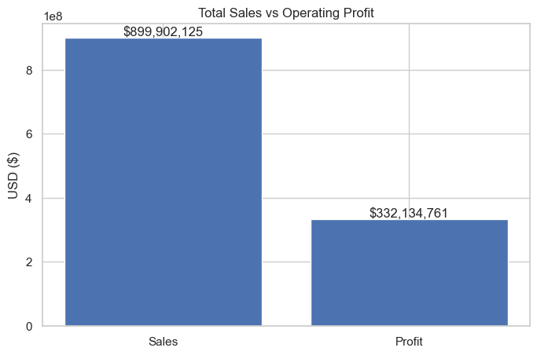

```python
plt.figure(figsize=(8,5))
bars = plt.bar(
    ["Sales", "Profit"],
    [total_sales, total_profit]
)

plt.title("Total Sales vs Operating Profit")
plt.ylabel("USD ($)")
plt.bar_label(bars, labels=[f"${total_sales:,.0f}", f"${total_profit:,.0f}"])
plt.show()
```

```python
# Group by Product Category
product_summary = (
    df
    .groupby("Product")
    .agg(
        Total_Sales=("Total Sales", "sum"),
        Total_Profit=("Operating Profit", "sum"),
        Avg_Margin=("Operating Margin", "mean"),
        Units_Sold=("Units Sold", "sum")
    )
    .sort_values("Total_Sales", ascending=False)
)

product_summary
```

| Product | Total_Sales | Total_Profit | Avg_Margin | Units_Sold |
| --- | --- | --- | --- | --- |
| Men's Street Footwear | 208826244.0 | 82802260.62 | 0.446130 | 593320 |
| Women's Apparel | 179038860.0 | 68650970.56 | 0.441318 | 433827 |
| Men's Athletic Footwear | 153673680.0 | 51846888.19 | 0.402702 | 435526 |
| Women's Street Footwear | 128002813.0 | 45095826.81 | 0.410199 | 392269 |
| Men's Apparel | 123728632.0 | 44763030.33 | 0.413225 | 306683 |
| Women's Athletic Footwear | 106631896.0 | 38975784.94 | 0.424359 | 317236 |

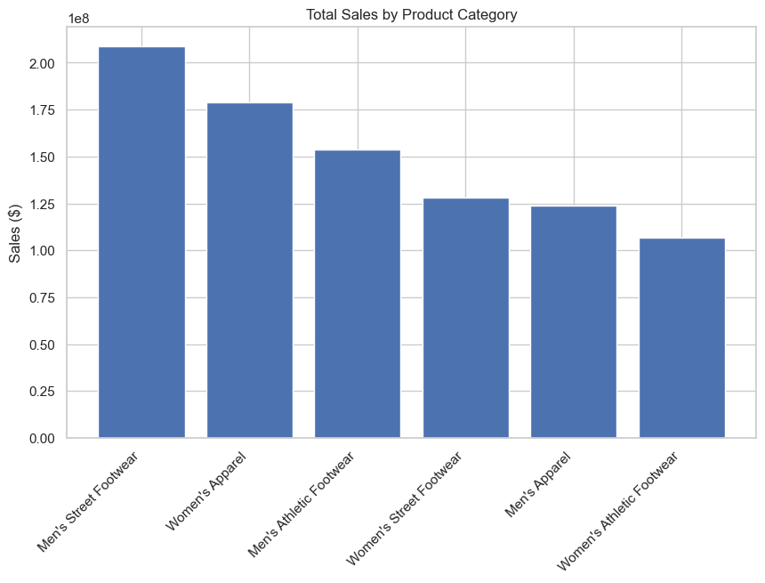

```python
plt.figure(figsize=(10,6))
plt.bar(product_summary.index, product_summary["Total_Sales"])
plt.xticks(rotation=45, ha="right")
plt.title("Total Sales by Product Category")
plt.ylabel("Sales ($)")
plt.show()
```

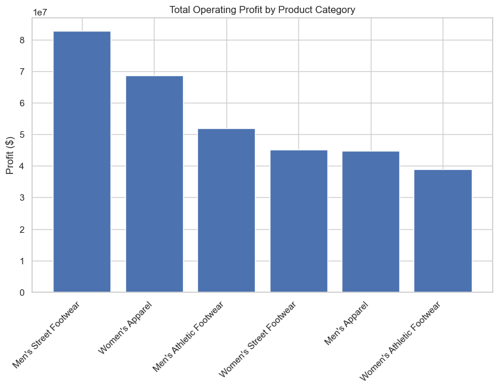

```python
plt.figure(figsize=(10,6))
plt.bar(product_summary.index, product_summary["Total_Profit"])
plt.xticks(rotation=45, ha="right")
plt.title("Total Operating Profit by Product Category")
plt.ylabel("Profit ($)")
plt.show()
```

```python
product_summary["Profit_per_Unit"] = (
    product_summary["Total_Profit"] / product_summary["Units_Sold"]
)

product_summary
```

| Product | Total_Sales | Total_Profit | Avg_Margin | Units_Sold | Profit_per_Unit |
| --- | --- | --- | --- | --- | --- |
| Men's Street Footwear | 208826244.0 | 82802260.62 | 0.446130 | 593320 | 139.557508 |
| Women's Apparel | 179038860.0 | 68650970.56 | 0.441318 | 433827 | 158.245039 |
| Men's Athletic Footwear | 153673680.0 | 51846888.19 | 0.402702 | 435526 | 119.044301 |
| Women's Street Footwear | 128002813.0 | 45095826.81 | 0.410199 | 392269 | 114.961485 |
| Men's Apparel | 123728632.0 | 44763030.33 | 0.413225 | 306683 | 145.958629 |
| Women's Athletic Footwear | 106631896.0 | 38975784.94 | 0.424359 | 317236 | 122.860536 |

**Top Revenue Driver**: Men’s Street Footwear is the largest revenue generator with over $209M in sales. It also has the highest unit volume (593K units) and a Strong margin of 44.6%

**Most Profitable Category (Per Unit)**: Women’s Apparel has the highest profit per unit ($158.25), while also holding the second-highest total profit and a very strong margin (44.1%).

**Volume vs Margin Trade-off**: Men’s Athletic Footwear has a high volume and the Lowest margin (40.27%), while also having a Lowe profit per unit. This suggests that there is competitive pricing, Higher production or distribution costs

**Apparel vs Footwear Comparison**:

```python
region_summary = (
    df
    .groupby("Region")
    .agg(
        Total_Sales=("Total Sales", "sum"),
        Total_Profit=("Operating Profit", "sum"),
        Avg_Margin=("Operating Margin", "mean"),
        Units_Sold=("Units Sold", "sum")
    )
    .sort_values("Total_Sales", ascending=False)
)

region_summary
```

| Region | Total_Sales | Total_Profit | Avg_Margin | Units_Sold |
| --- | --- | --- | --- | --- |
| West | 269943182.0 | 89609406.55 | 0.396691 | 686985 |
| Northeast | 186324067.0 | 68020587.65 | 0.410450 | 501279 |
| Southeast | 163171236.0 | 60555416.70 | 0.419167 | 407000 |
| South | 144663181.0 | 61138004.07 | 0.466898 | 492260 |
| Midwest | 135800459.0 | 52811346.48 | 0.435272 | 391337 |

**Key Regional Insights**

1. **Highest Sales & Profit Region**
- West is the top-performing region by:
  - **Sales** (\$270M)
  - **Profit** (\$89.6M)
  - **Units sold** (687K)

The West is Adidas’ largest and most influential market.

2. **Most Efficient Region (Margin Leader)**
- South leads in average operating margin:
  - 46.7%, the highest of all regions
  - Strong profit despite lower sales than West/Northeast

The South is a high-efficiency, high-margin market — an excellent candidate for expansion.

3. **Sales vs Margin Trade-Off**
- **West**:
  - Highest sales
  - Lowest margin among regions
  - Suggests higher competition, discounting, or operating costs
- **Midwest & South**:
  - Lower sales
  - Higher margins

Indicates pricing pressure in large coastal markets and stronger pricing power inland.

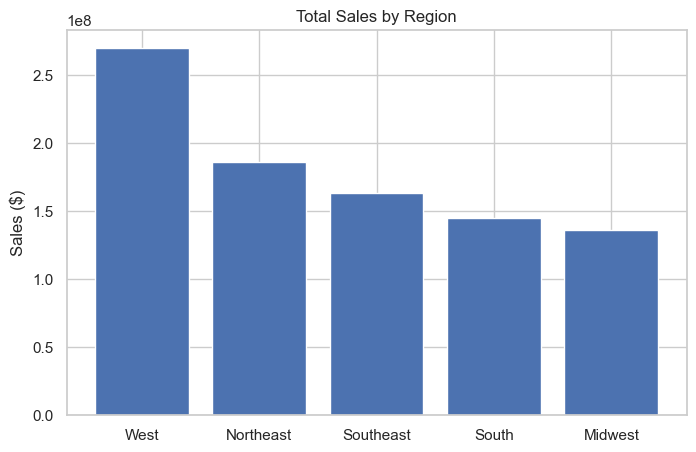

```python
plt.figure(figsize=(8,5))
plt.bar(region_summary.index, region_summary["Total_Sales"])
plt.title("Total Sales by Region")
plt.ylabel("Sales ($)")
plt.show()
```

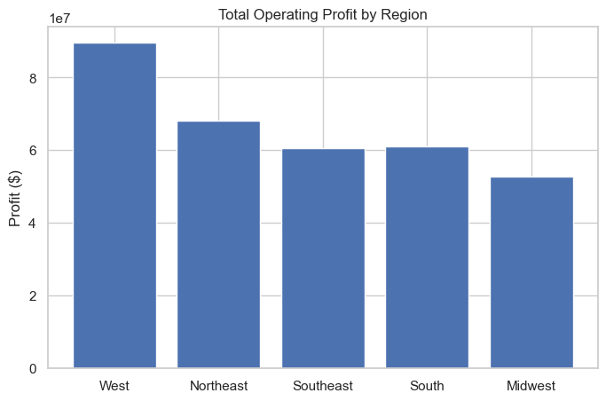

```python
plt.figure(figsize=(8,5))
plt.bar(region_summary.index, region_summary["Total_Profit"])
plt.title("Total Operating Profit by Region")
plt.ylabel("Profit ($)")
plt.show()
```

```python
city_summary = (
    df
    .groupby("City")
    .agg(
        Total_Sales=("Total Sales", "sum"),
        Total_Profit=("Operating Profit", "sum"),
        Avg_Margin=("Operating Margin", "mean"),
        Units_Sold=("Units Sold", "sum")
    )
    .sort_values("Total_Sales", ascending=False)
)

city_summary.head(10)
```

| City | Total_Sales | Total_Profit | Avg_Margin | Units_Sold |
| --- | --- | --- | --- | --- |
| Charleston | 39974797.0 | 15607190.11 | 0.444931 | 102483 |
| New York | 39801235.0 | 13899973.16 | 0.396389 | 111954 |
| San Francisco | 34539220.0 | 10256249.56 | 0.357685 | 86900 |
| Miami | 31600863.0 | 12168619.11 | 0.429167 | 73135 |
| Portland | 30545652.0 | 10760799.37 | 0.407722 | 72946 |
| Orlando | 27682851.0 | 8757587.81 | 0.364259 | 60295 |
| Seattle | 26330718.0 | 6991403.13 | 0.325069 | 46611 |
| Los Angeles | 25634913.0 | 9044920.84 | 0.416019 | 76384 |
| Houston | 25456882.0 | 9845141.06 | 0.435880 | 90322 |
| Albany | 24427804.0 | 9429850.91 | 0.426250 | 57186 |

**Insights**

1. **Top Revenue City**: Charleston narrowly leads in sales and dominates in margin. The city also has strong profitability suggests that there might be a favorable cost structure or strong local demand of adidas products.
2. **High Sales, Lower Margin Cities**: New York, San Francisco, Seattle has high revenue but with lower margins (32–39%). This suggests that these are strategic but expensive markets. Focus on efficiency, not discounting.
3. **High Margin Cities**: Charleston, Houston, Miami, Albany have strong margins (>42%) and a balanced sales volumes. They are Ideal markets for expanding premium product lines.

```python
sales_method_summary = (
    df
    .groupby("Sales Method")
    .agg(
        Total_Sales=("Total Sales", "sum"),
        Total_Profit=("Operating Profit", "sum"),
        Avg_Margin=("Operating Margin", "mean"),
        Units_Sold=("Units Sold", "sum")
    )
    .sort_values("Total_Sales", ascending=False)
)

sales_method_summary
```

| Sales Method | Total_Sales | Total_Profit | Avg_Margin | Units_Sold |
| --- | --- | --- | --- | --- |
| In-store | 356643750.0 | 1.275913e+08 | 0.356121 | 689990 |
| Outlet | 295585493.0 | 1.079883e+08 | 0.394876 | 849778 |
| Online | 247672882.0 | 9.655518e+07 | 0.464152 | 939093 |

1. **Revenue Leader**
   - In-store is the largest revenue generator (~$356.6M).
   - Indicates strong brick-and-mortar performance and higher average ticket values.
2. **Volume Leader**
   - Online sells the most units (~939K).
   - This suggests that there is broader reach, lower friction purchasing and possibly lower average selling price per unit.
3. **Profitability & Margin Efficiency**
   - Online has the highest operating margin (46.4%), despite lower total sales than In-store.
   - Outlet sits in the middle:
     - High unit volume
     - Moderate margin (39.5%)
   - In-store has the lowest margin (35.6%), likely due to:
     - Higher operating costs (rent, staff)
     - Promotional activity

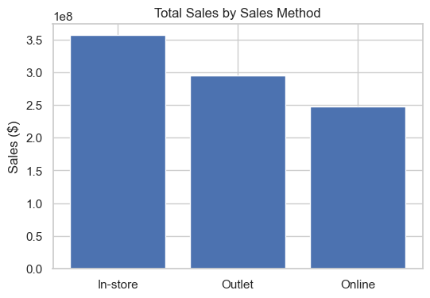

```python
plt.figure(figsize=(6,4))
plt.bar(
    sales_method_summary.index,
    sales_method_summary["Total_Sales"]
)
plt.title("Total Sales by Sales Method")
plt.ylabel("Sales ($)")
plt.show()
```

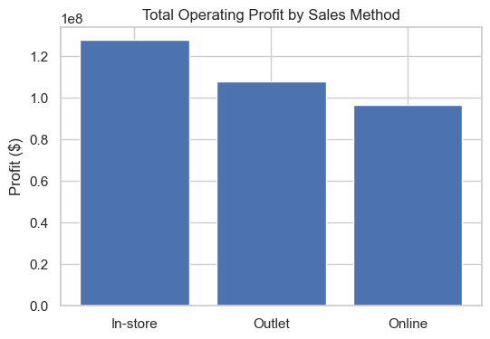

```python
plt.figure(figsize=(6,4))
plt.bar(
    sales_method_summary.index,
    sales_method_summary["Total_Profit"]
)
plt.title("Total Operating Profit by Sales Method")
plt.ylabel("Profit ($)")
plt.show()
```

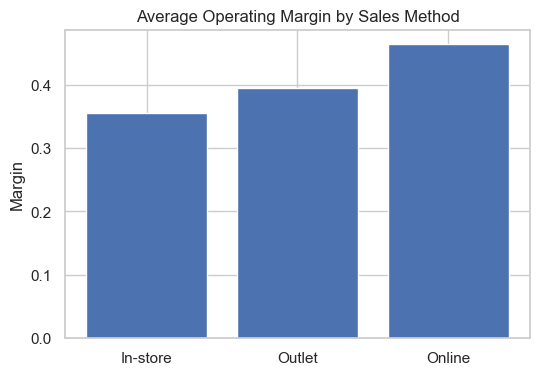

```python
plt.figure(figsize=(6,4))
plt.bar(
    sales_method_summary.index,
    sales_method_summary["Avg_Margin"]
)
plt.title("Average Operating Margin by Sales Method")
plt.ylabel("Margin")
plt.show()
```

```python
# Ensure datetime
df["Invoice Date"] = pd.to_datetime(df["Invoice Date"])

# Monthly aggregation (month-end internally, but we'll relabel)
monthly_sales = (
    df
    .set_index("Invoice Date")
    .resample("ME")
    .agg(
        Total_Sales=("Total Sales", "sum"),
        Total_Profit=("Operating Profit", "sum"),
        Units_Sold=("Units Sold", "sum")
    )
)

# Convert index to readable Month Year
monthly_sales.index = monthly_sales.index.strftime("%B %Y")

monthly_sales
```

| Invoice Date | Total_Sales | Total_Profit | Units_Sold |
| --- | --- | --- | --- |
| January 2020 | 16253746.0 | 5830005.41 | 48333 |
| February 2020 | 14997988.0 | 5207354.44 | 37846 |
| March 2020 | 17660577.0 | 5862006.26 | 46972 |
| April 2020 | 24607006.0 | 9301293.34 | 54709 |
| May 2020 | 16918014.0 | 5870841.95 | 35705 |
| June 2020 | 8829819.0 | 2292727.41 | 16269 |
| July 2020 | 17146013.0 | 4917665.11 | 38219 |
| August 2020 | 19877980.0 | 7338924.54 | 62307 |
| September 2020 | 18304436.0 | 7119702.44 | 46125 |
| October 2020 | 10836269.0 | 4139469.21 | 30167 |
| November 2020 | 8622300.0 | 2783476.24 | 25152 |
| December 2020 | 8026527.0 | 2712196.23 | 20545 |
| January 2021 | 55225396.0 | 19311929.10 | 179299 |
| February 2021 | 46102165.0 | 16185382.26 | 156113 |
| March 2021 | 39148532.0 | 14577781.74 | 143988 |
| April 2021 | 47732964.0 | 18257943.97 | 161717 |
| May 2021 | 63589681.0 | 24075413.38 | 178900 |
| June 2021 | 65917553.0 | 24421988.51 | 164745 |
| July 2021 | 78334681.0 | 29137233.48 | 180481 |
| August 2021 | 72288221.0 | 27112515.76 | 195414 |
| September 2021 | 59357023.0 | 23889884.29 | 182425 |
| October 2021 | 53074764.0 | 20938975.39 | 152834 |
| November 2021 | 59235040.0 | 21972045.19 | 149350 |
| December 2021 | 77815430.0 | 28878005.80 | 171246 |

**1.** **Overall Trend**

- There is a clear upward trend from 2020 to 2021:
  - Early 2020 sales are relatively low
  - 2021 shows substantially higher sales, profit, and units sold
- This suggests:
  - Market recovery after early 2020 disruption
  - Strong growth momentum going into late 2021

**2.** **Early 2020 Dip**

**3.** **Recovery & Growth Phase**

This Indicates:

- Strong demand rebound
- Effective channel mix (especially online)
- Seasonal strength layered on top of growth

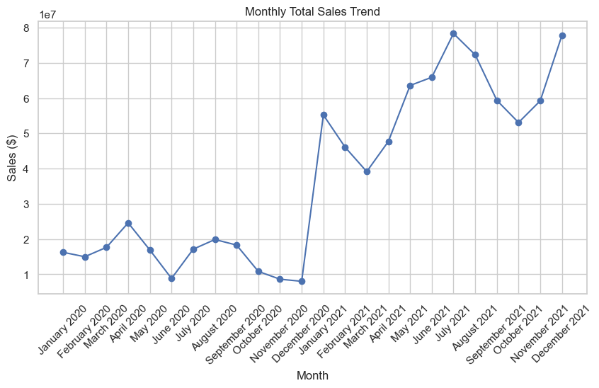

```python
plt.figure(figsize=(10,5))
plt.plot(monthly_sales.index, monthly_sales["Total_Sales"], marker="o")
plt.title("Monthly Total Sales Trend")
plt.xlabel("Month")
plt.ylabel("Sales ($)")
plt.xticks(rotation=45)
plt.grid(True)
plt.show()
```

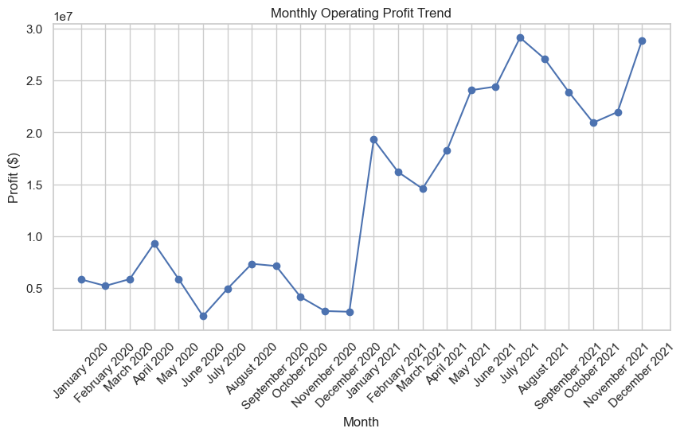

```python
plt.figure(figsize=(10,5))
plt.plot(monthly_sales.index, monthly_sales["Total_Profit"], marker="o")
plt.title("Monthly Operating Profit Trend")
plt.xlabel("Month")
plt.ylabel("Profit ($)")
plt.xticks(rotation=45)
plt.grid(True)
plt.show()
```

```python
# Extract month names
df["Month"] = df["Invoice Date"].dt.month_name()

seasonality = (
    df
    .groupby("Month")
    .agg(
        Avg_Monthly_Sales=("Total Sales", "mean"),
        Avg_Monthly_Profit=("Operating Profit", "mean"),
        Avg_Units_Sold=("Units Sold", "mean")
    )
)

# Correct calendar order
month_order = [
    "January","February","March","April","May","June",
    "July","August","September","October","November","December"
]

seasonality = seasonality.reindex(month_order)

seasonality
```

| Month | Avg_Monthly_Sales | Avg_Monthly_Profit | Avg_Units_Sold |
| --- | --- | --- | --- |
| January | 83018.747967 | 29200.853089 | 264.380952 |
| February | 78737.310567 | 27567.959665 | 249.947165 |
| March | 70834.300499 | 25486.019950 | 238.104738 |
| April | 86016.611177 | 32769.604411 | 257.343639 |
| May | 98180.115854 | 36519.823573 | 261.713415 |
| June | 102534.117970 | 36645.700850 | 248.304527 |
| July | 123360.069767 | 43998.576990 | 282.558140 |
| August | 108049.473623 | 40388.558382 | 302.134818 |
| September | 94249.343447 | 37632.993604 | 277.366505 |
| October | 78514.782555 | 30808.900000 | 224.816953 |
| November | 85355.144654 | 31139.020667 | 219.499371 |
| December | 113098.757576 | 41620.819539 | 252.689065 |

| **Month** | **Avg Monthly Sales** | **Interpretation** |
| --- | --- | --- |
| July | 123,360 | Highest average sales |
| December | 113,099 | Strong holiday effect |
| August | 108,049 | Back-to-school boost |
| June | 102,534 | Start of summer demand |
| May | 98,180 | Seasonal ramp-up |
| January | 83,019 | Post-holiday slowdown |
| February | 78,737 | Low demand |
| March | 70,834 | Lowest average sales |

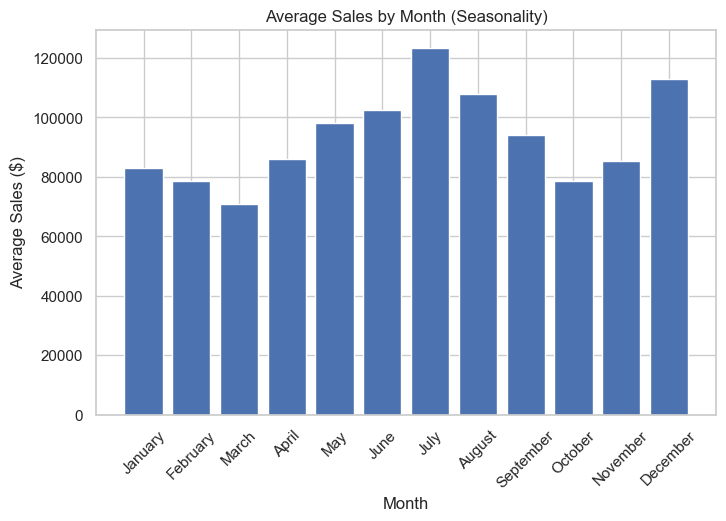

```python
plt.figure(figsize=(8,5))
plt.bar(seasonality.index, seasonality["Avg_Monthly_Sales"])
plt.title("Average Sales by Month (Seasonality)")
plt.xlabel("Month")
plt.ylabel("Average Sales ($)")
plt.xticks(rotation=45)
plt.show()
```

```python
product_margin_risk = (
    df
    .groupby("Product")
    .agg(
        Avg_Margin=("Operating Margin", "mean"),
        Total_Sales=("Total Sales", "sum"),
        Total_Profit=("Operating Profit", "sum"),
        Units_Sold=("Units Sold", "sum")
    )
    .sort_values("Avg_Margin")
)

product_margin_risk
```

| Product | Avg_Margin | Total_Sales | Total_Profit | Units_Sold |
| --- | --- | --- | --- | --- |
| Men's Athletic Footwear | 0.402702 | 153673680.0 | 51846888.19 | 435526 |
| Women's Street Footwear | 0.410199 | 128002813.0 | 45095826.81 | 392269 |
| Men's Apparel | 0.413225 | 123728632.0 | 44763030.33 | 306683 |
| Women's Athletic Footwear | 0.424359 | 106631896.0 | 38975784.94 | 317236 |
| Women's Apparel | 0.441318 | 179038860.0 | 68650970.56 | 433827 |
| Men's Street Footwear | 0.446130 | 208826244.0 | 82802260.62 | 593320 |

```python
region_margin_risk = (
    df
    .groupby("Region")
    .agg(
        Avg_Margin=("Operating Margin", "mean"),
        Total_Sales=("Total Sales", "sum"),
        Total_Profit=("Operating Profit", "sum"),
        Units_Sold=("Units Sold", "sum")
    )
    .sort_values("Avg_Margin")
)

region_margin_risk
```

| Region | Avg_Margin | Total_Sales | Total_Profit | Units_Sold |
| --- | --- | --- | --- | --- |
| West | 0.396691 | 269943182.0 | 89609406.55 | 686985 |
| Northeast | 0.410450 | 186324067.0 | 68020587.65 | 501279 |
| Southeast | 0.419167 | 163171236.0 | 60555416.70 | 407000 |
| Midwest | 0.435272 | 135800459.0 | 52811346.48 | 391337 |
| South | 0.466898 | 144663181.0 | 61138004.07 | 492260 |

```python
sales_method_margin_risk = (
    df
    .groupby("Sales Method")
    .agg(
        Avg_Margin=("Operating Margin", "mean"),
        Total_Sales=("Total Sales", "sum"),
        Total_Profit=("Operating Profit", "sum"),
        Units_Sold=("Units Sold", "sum")
    )
    .sort_values("Avg_Margin")
)

sales_method_margin_risk
```

| Sales Method | Avg_Margin | Total_Sales | Total_Profit | Units_Sold |
| --- | --- | --- | --- | --- |
| In-store | 0.356121 | 356643750.0 | 1.275913e+08 | 689990 |
| Outlet | 0.394876 | 295585493.0 | 1.079883e+08 | 849778 |
| Online | 0.464152 | 247672882.0 | 9.655518e+07 | 939093 |

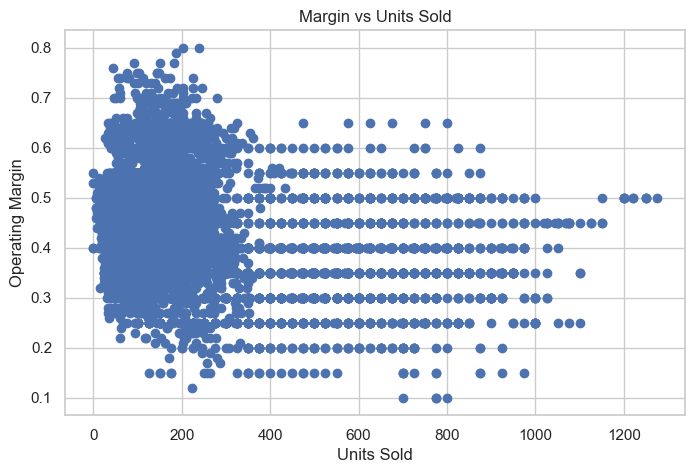

```python
plt.figure(figsize=(8,5))
plt.scatter(
    df["Units Sold"],
    df["Operating Margin"]
)
plt.title("Margin vs Units Sold")
plt.xlabel("Units Sold")
plt.ylabel("Operating Margin")
plt.show()
```

```python
# Recreate monthly data with datetime index for forecasting
df["Invoice Date"] = pd.to_datetime(df["Invoice Date"])

monthly_ts = (
    df
    .set_index("Invoice Date")
    .resample("ME")
    .agg(
        Total_Sales=("Total Sales", "sum")
    )
)

monthly_ts
```

| Invoice Date | Total_Sales |
| --- | --- |
| 2020-01-31 | 16253746.0 |
| 2020-02-29 | 14997988.0 |
| 2020-03-31 | 17660577.0 |
| 2020-04-30 | 24607006.0 |
| 2020-05-31 | 16918014.0 |
| 2020-06-30 | 8829819.0 |
| 2020-07-31 | 17146013.0 |
| 2020-08-31 | 19877980.0 |
| 2020-09-30 | 18304436.0 |
| 2020-10-31 | 10836269.0 |
| 2020-11-30 | 8622300.0 |
| 2020-12-31 | 8026527.0 |
| 2021-01-31 | 55225396.0 |
| 2021-02-28 | 46102165.0 |
| 2021-03-31 | 39148532.0 |
| 2021-04-30 | 47732964.0 |
| 2021-05-31 | 63589681.0 |
| 2021-06-30 | 65917553.0 |
| 2021-07-31 | 78334681.0 |
| 2021-08-31 | 72288221.0 |
| 2021-09-30 | 59357023.0 |
| 2021-10-31 | 53074764.0 |
| 2021-11-30 | 59235040.0 |
| 2021-12-31 | 77815430.0 |

```
================================================================================
SECTION 1: STATISTICAL SIGNIFICANCE TESTING
================================================================================

Regional Operating Margin Differences
------------------------------------------------------------
ANOVA F-stat: 160.7863, p-value: 0.000000
Levene test: p-value = 0.000000
Kruskal-Wallis: H=518.9382, p-value=0.000000
✓ Mean differences statistically significant (ANOVA).
⚠ Variances unequal → rely more on Kruskal result.
✓ Robust test confirms significant differences.

Product Operating Margin Differences
------------------------------------------------------------
ANOVA F-stat: 54.0363, p-value: 0.000000
Levene test: p-value = 0.000000
Kruskal-Wallis: H=287.9745, p-value=0.000000
✓ Mean differences statistically significant (ANOVA).
⚠ Variances unequal → rely more on Kruskal result.
✓ Robust test confirms significant differences.

================================================================================
SECTION 2: CORRELATION ANALYSIS
================================================================================

Key Pearson correlations:
                  Price per Unit  Units Sold  Total Sales  Operating Profit  \
Price per Unit             1.000       0.266        0.436             0.395
Units Sold                 0.266       1.000        0.913             0.892
Total Sales                0.436       0.913        1.000             0.956
Operating Profit           0.395       0.892        0.956             1.000
Operating Margin          -0.137      -0.305       -0.365            -0.212

                  Operating Margin
Price per Unit              -0.137
Units Sold                  -0.305
Total Sales                 -0.365
Operating Profit            -0.212
Operating Margin             1.000

Key Spearman correlations (robust):
                  Price per Unit  Units Sold  Total Sales  Operating Profit  \
Price per Unit             1.000       0.261        0.476             0.457
Units Sold                 0.261       1.000        0.922             0.913
Total Sales                0.476       0.922        1.000             0.988
Operating Profit           0.457       0.913        0.988             1.000
Operating Margin          -0.131      -0.352       -0.440            -0.324

                  Operating Margin
Price per Unit              -0.131
Units Sold                  -0.352
Total Sales                 -0.440
Operating Profit            -0.324
Operating Margin             1.000
```

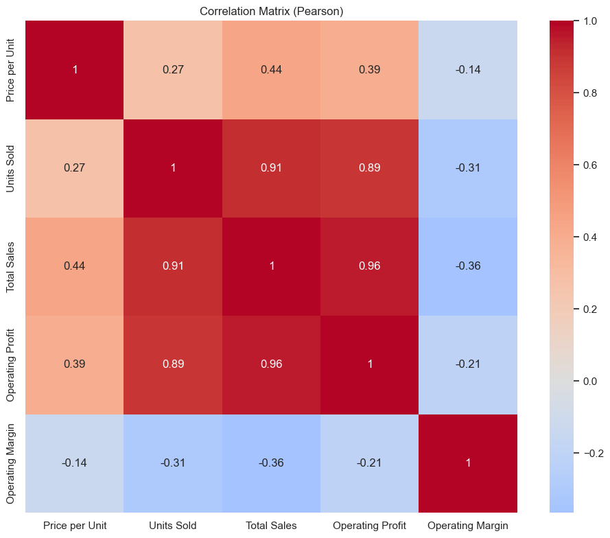

```
================================================================================
SECTION 3: MARKET SEGMENTATION (K-MEANS)
================================================================================

Cluster Summary:
         Total Sales  Operating Margin  Units Sold  Profit_per_Unit
Cluster
0        21399203.27              0.40    60834.27           120.42
1        28223479.00              0.48    73215.00           165.68
2        30884200.43              0.43    93419.71           124.13
3        50151426.60              0.40   128648.20           132.17
```

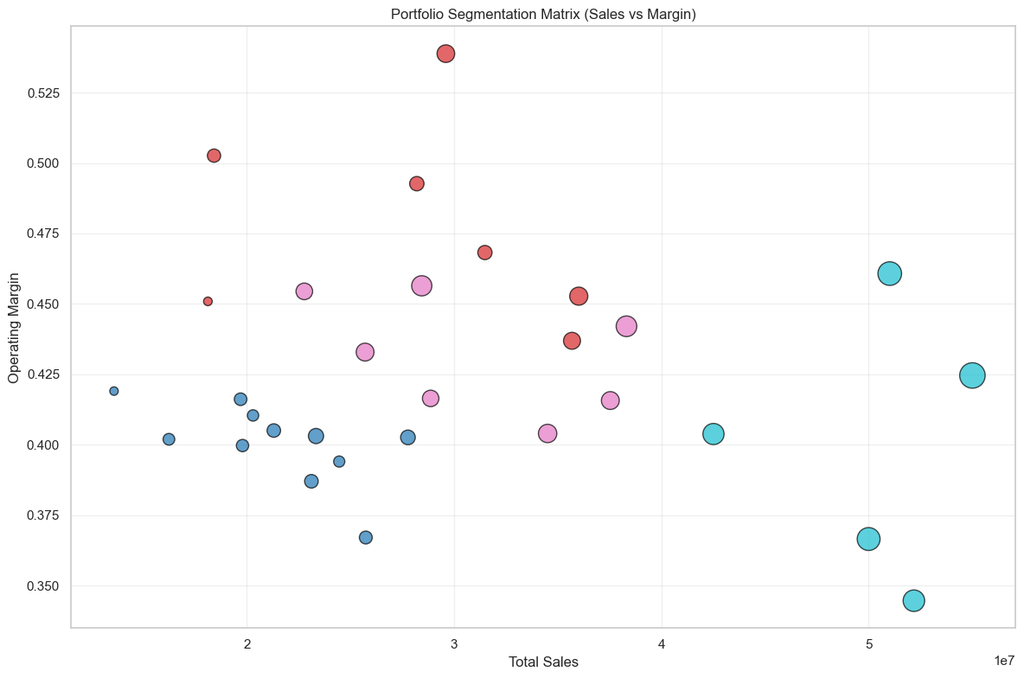

```
================================================================================
SECTION 4: ADVANCED FORECASTING
================================================================================

Backtest Results:
MAE:  $8,844,483
RMSE: $11,111,450
```

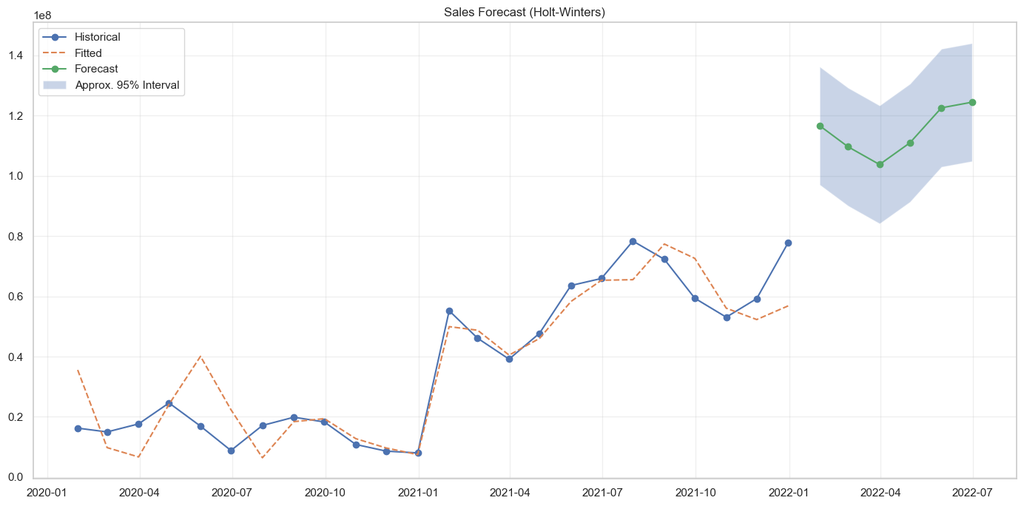

```
================================================================================
SECTION 5: OPTIMIZATION & SCENARIO ANALYSIS
================================================================================

Top 10 Segments to Invest In:
                      Product     Region Sales Method  Total Sales  \
53            Women's Apparel      South       Outlet   16812695.0
52            Women's Apparel      South       Online   12258242.0
46            Women's Apparel    Midwest       Online    8336383.0
55            Women's Apparel  Southeast       Online   16515423.0
67  Women's Athletic Footwear      South       Online    7078723.0
40      Men's Street Footwear  Southeast       Online   19346750.0
68  Women's Athletic Footwear      South       Outlet   10808249.0
37      Men's Street Footwear      South       Online   13865365.0
31      Men's Street Footwear    Midwest       Online   11159060.0
82    Women's Street Footwear      South       Online    7832008.0

    Operating Profit  Operating Margin  Efficiency_Score
53        9279642.22          0.535764          8.913849
52        5187751.05          0.546028          8.912116
46        3705078.17          0.527680          8.409189
55        7353111.64          0.500682          8.321234
67        2913307.42          0.516571          8.147677
40        8176805.70          0.482803          8.100486
68        5354575.41          0.491944          7.967444
37        5591205.69          0.482695          7.937874
31        4281685.21          0.477423          7.747502
82        3172122.53          0.482128          7.653164

Scenario: Improve low-margin segments by 5pp
Additional Profit: $12,770,129
New Total Profit: $344,904,891

================================================================================
ADVANCED ANALYTICS MODULE COMPLETE
================================================================================
```

```python
# ============================================================================
# ADVANCED ANALYTICS MODULE (FINAL VERSION)
# ============================================================================
# This module extends the core analysis with:
# 1) Statistical validation (ANOVA + robustness checks)
# 2) Correlation analysis (Pearson + Spearman)
# 3) Market segmentation using K-Means clustering
# 4) Advanced forecasting (Holt-Winters with safeguards)
# 5) Optimization & scenario analysis
#
# All logic is defensively coded to avoid statistical misuse.
# ============================================================================

import warnings
warnings.filterwarnings("ignore")

import numpy as np
import pandas as pd

import matplotlib.pyplot as plt
import seaborn as sns

from scipy import stats
from scipy.stats import levene, kruskal

from sklearn.cluster import KMeans
from sklearn.preprocessing import StandardScaler
from sklearn.metrics import silhouette_score
from sklearn.metrics import mean_absolute_error, mean_squared_error

from statsmodels.tsa.holtwinters import ExponentialSmoothing


# ============================================================================
# BASIC SAFETY & TYPE CHECKS
# ============================================================================
df["Invoice Date"] = pd.to_datetime(df["Invoice Date"])

numeric_cols = [
    "Price per Unit", "Units Sold", "Total Sales",
    "Operating Profit", "Operating Margin"
]
df[numeric_cols] = df[numeric_cols].apply(pd.to_numeric, errors="coerce")

df_clean = df.dropna(subset=[
    "Region", "Product", "Sales Method",
    "Total Sales", "Operating Profit",
    "Operating Margin", "Units Sold"
])


# ============================================================================
# SECTION 1: STATISTICAL SIGNIFICANCE TESTING
# ============================================================================
print("=" * 80)
print("SECTION 1: STATISTICAL SIGNIFICANCE TESTING")
print("=" * 80)

def anova_with_robust_checks(groups, label):
    groups = [g for g in groups if len(g) > 0]

    f_stat, p_anova = stats.f_oneway(*groups)
    lev_stat, p_lev = levene(*groups, center="median")
    h_stat, p_kw = kruskal(*groups)

    print(f"\n{label}")
    print("-" * 60)
    print(f"ANOVA F-stat: {f_stat:.4f}, p-value: {p_anova:.6f}")
    print(f"Levene test: p-value = {p_lev:.6f}")
    print(f"Kruskal-Wallis: H={h_stat:.4f}, p-value={p_kw:.6f}")

    if p_anova < 0.05:
        print("✓ Mean differences statistically significant (ANOVA).")
    else:
        print("✗ No significant mean differences detected (ANOVA).")

    if p_lev < 0.05:
        print("⚠ Variances unequal → rely more on Kruskal result.")

    if p_kw < 0.05:
        print("✓ Robust test confirms significant differences.")
    else:
        print("✗ Robust test does NOT confirm differences.")

# Regional margins
regions = df_clean["Region"].unique()
region_groups = [df_clean[df_clean["Region"] == r]["Operating Margin"].values for r in regions]
anova_with_robust_checks(region_groups, "Regional Operating Margin Differences")

# Product margins
products = df_clean["Product"].unique()
product_groups = [df_clean[df_clean["Product"] == p]["Operating Margin"].values for p in products]
anova_with_robust_checks(product_groups, "Product Operating Margin Differences")


# ============================================================================
# SECTION 2: CORRELATION ANALYSIS
# ============================================================================
print("\n" + "=" * 80)
print("SECTION 2: CORRELATION ANALYSIS")
print("=" * 80)

corr_vars = [
    "Price per Unit", "Units Sold",
    "Total Sales", "Operating Profit",
    "Operating Margin"
]

pearson_corr = df_clean[corr_vars].corr(method="pearson")
spearman_corr = df_clean[corr_vars].corr(method="spearman")

print("\nKey Pearson correlations:")
print(pearson_corr.round(3))

print("\nKey Spearman correlations (robust):")
print(spearman_corr.round(3))

plt.figure(figsize=(10, 8))
sns.heatmap(pearson_corr, annot=True, cmap="coolwarm", center=0, square=True)
plt.title("Correlation Matrix (Pearson)")
plt.tight_layout()
plt.show()


# ============================================================================
# SECTION 3: MARKET SEGMENTATION (K-MEANS)
# ============================================================================
print("\n" + "=" * 80)
print("SECTION 3: MARKET SEGMENTATION (K-MEANS)")
print("=" * 80)

segment_df = (
    df_clean
    .groupby(["Product", "Region"])
    .agg({
        "Total Sales": "sum",
        "Operating Profit": "sum",
        "Operating Margin": "mean",
        "Units Sold": "sum"
    })
    .reset_index()
)

segment_df["Profit_per_Unit"] = np.where(
    segment_df["Units Sold"] > 0,
    segment_df["Operating Profit"] / segment_df["Units Sold"],
    np.nan
)

segment_df.dropna(inplace=True)

features = ["Total Sales", "Operating Margin", "Units Sold", "Profit_per_Unit"]
X = segment_df[features]

scaler = StandardScaler()
X_scaled = scaler.fit_transform(X)

inertias, silhouettes = [], []
for k in range(2, 8):
    km = KMeans(n_clusters=k, random_state=42, n_init=10)
    labels = km.fit_predict(X_scaled)
    inertias.append(km.inertia_)
    silhouettes.append(silhouette_score(X_scaled, labels))

optimal_k = 4
kmeans = KMeans(n_clusters=optimal_k, random_state=42, n_init=10)
segment_df["Cluster"] = kmeans.fit_predict(X_scaled)

cluster_summary = segment_df.groupby("Cluster")[features].mean().round(2)
print("\nCluster Summary:")
print(cluster_summary)

sales_med = cluster_summary["Total Sales"].median()
margin_med = cluster_summary["Operating Margin"].median()

def label_cluster(row):
    if row["Total Sales"] > sales_med and row["Operating Margin"] > margin_med:
        return "High Sales / High Margin (Stars)"
    elif row["Total Sales"] > sales_med:
        return "High Sales / Low Margin (Optimize)"
    elif row["Operating Margin"] > margin_med:
        return "Low Sales / High Margin (Niche)"
    else:
        return "Low Sales / Low Margin (Deprioritize)"

segment_df["Cluster_Name"] = segment_df.apply(
    lambda r: label_cluster(cluster_summary.loc[r["Cluster"]]),
    axis=1
)

plt.figure(figsize=(12, 8))
plt.scatter(
    segment_df["Total Sales"],
    segment_df["Operating Margin"],
    s=50 + 400 * (segment_df["Units Sold"] - segment_df["Units Sold"].min())
      / (segment_df["Units Sold"].max() - segment_df["Units Sold"].min()),
    c=segment_df["Cluster"],
    cmap="tab10",
    alpha=0.7,
    edgecolors="black"
)
plt.xlabel("Total Sales")
plt.ylabel("Operating Margin")
plt.title("Portfolio Segmentation Matrix (Sales vs Margin)")
plt.grid(True, alpha=0.3)
plt.tight_layout()
plt.show()


# ============================================================================
# SECTION 4: ADVANCED FORECASTING (SEASONAL SAFE)
# ============================================================================
print("\n" + "=" * 80)
print("SECTION 4: ADVANCED FORECASTING")
print("=" * 80)

monthly_ts = (
    df_clean
    .set_index("Invoice Date")
    .resample("ME")
    .agg({"Total Sales": "sum"})
)

model = ExponentialSmoothing(
    monthly_ts["Total Sales"],
    trend="add",
    seasonal="add",
    seasonal_periods=12
).fit()

# Backtest with safeguard
h = 3
train = monthly_ts.iloc[:-h]
test = monthly_ts.iloc[-h:]

if len(train) >= 24:
    bt_model = ExponentialSmoothing(
        train["Total Sales"],
        trend="add",
        seasonal="add",
        seasonal_periods=12
    ).fit()
else:
    bt_model = ExponentialSmoothing(
        train["Total Sales"],
        trend="add",
        seasonal=None
    ).fit()

bt_forecast = bt_model.forecast(h)

print("\nBacktest Results:")
print(f"MAE:  ${mean_absolute_error(test['Total Sales'], bt_forecast):,.0f}")
print(f"RMSE: ${np.sqrt(mean_squared_error(test['Total Sales'], bt_forecast)):,.0f}")

forecast_steps = 6
forecast = model.forecast(forecast_steps)

residuals = monthly_ts["Total Sales"] - model.fittedvalues
sigma = residuals.std()
z = 1.96

forecast_index = pd.date_range(
    start=monthly_ts.index[-1] + pd.offsets.MonthEnd(1),
    periods=forecast_steps,
    freq="ME"
)

forecast_df = pd.DataFrame({
    "Forecast": forecast,
    "Lower_95_Approx": forecast - z * sigma,
    "Upper_95_Approx": forecast + z * sigma
}, index=forecast_index)

plt.figure(figsize=(14, 7))
plt.plot(monthly_ts.index, monthly_ts["Total Sales"], label="Historical", marker="o")
plt.plot(monthly_ts.index, model.fittedvalues, label="Fitted", linestyle="--")
plt.plot(forecast_df.index, forecast_df["Forecast"], label="Forecast", marker="o")
plt.fill_between(
    forecast_df.index,
    forecast_df["Lower_95_Approx"],
    forecast_df["Upper_95_Approx"],
    alpha=0.3,
    label="Approx. 95% Interval"
)
plt.legend()
plt.grid(True, alpha=0.3)
plt.title("Sales Forecast (Holt-Winters)")
plt.tight_layout()
plt.show()


# ============================================================================
# SECTION 5: OPTIMIZATION & SCENARIO ANALYSIS
# ============================================================================
print("\n" + "=" * 80)
print("SECTION 5: OPTIMIZATION & SCENARIO ANALYSIS")
print("=" * 80)

segment_opt = (
    df_clean
    .groupby(["Product", "Region", "Sales Method"])
    .agg({
        "Total Sales": "sum",
        "Operating Profit": "sum",
        "Operating Margin": "mean"
    })
    .reset_index()
)

segment_opt["Efficiency_Score"] = (
    segment_opt["Operating Margin"] * np.log1p(segment_opt["Total Sales"])
)

print("\nTop 10 Segments to Invest In:")
print(segment_opt.nlargest(10, "Efficiency_Score"))

low_margin_sales = df_clean[df_clean["Operating Margin"] < 0.35]["Total Sales"].sum()
current_profit = df_clean["Operating Profit"].sum()

gain = low_margin_sales * 0.05

print("\nScenario: Improve low-margin segments by 5pp")
print(f"Additional Profit: ${gain:,.0f}")
print(f"New Total Profit: ${current_profit + gain:,.0f}")

print("\n" + "=" * 80)
print("ADVANCED ANALYTICS MODULE COMPLETE")
print("=" * 80)
```

**Advanced Analytics**

**Purpose and Scope**

The Advanced Analytics Module extends the descriptive and diagnostic analyses by applying statistical validation, segmentation modeling, forecasting, and scenario analysis. The objective is to confirm whether observed performance differences are structurally significant, identify patterns not visible through aggregation alone, and provide decision-oriented insights that support strategic planning.

**Statistical Validation of Performance Differences**

Statistical tests were conducted to assess whether operating margin differences across regions and product categories are statistically significant. One-way analysis of variance (ANOVA) was used as the primary test, supplemented by non-parametric robustness checks to account for potential violations of variance assumptions.

The results indicate that operating margins differ meaningfully across both regions and product categories. These differences are therefore unlikely to be driven by random variation alone and reflect underlying structural characteristics of the business.

**Implication:** Region-specific and product-specific performance management strategies are empirically justified. Margin optimization initiatives should be targeted rather than uniform across the portfolio.

**Pricing, Volume, and Profitability Relationships**

Correlation analysis was performed to examine relationships among pricing, sales volume, revenue, and profitability.

**Implication:** Strategies focused exclusively on volume growth risk margin erosion. Sustainable profit growth requires balancing sales expansion with disciplined pricing and cost control.

**Market Segmentation and Portfolio Structure**

K-Means clustering was applied to product–region combinations using sales scale, operating margin, units sold, and profit efficiency. This analysis identified distinct performance clusters representing structurally different business segments.

The resulting segments can be interpreted as: - High-sales, high-margin segments: Core value drivers that warrant continued investment and protection. - High-sales, low-margin segments: Scale-driven segments with significant margin improvement potential. - Low-sales, high-margin segments: Efficient niche opportunities that may benefit from targeted growth. - Low-sales, low-margin segments: Areas suitable for cost optimization or reduced strategic focus.

**Implication:** Not all revenue contributes equally to profitability. Portfolio decisions should prioritize efficiency-adjusted performance rather than revenue alone, enabling more effective resource allocation.

**Sales Forecasting and Demand Outlook**

A Holt–Winters Exponential Smoothing model was used to forecast monthly sales, incorporating both trend and seasonality. The model projects continued sales growth over the forecast horizon, with recurring seasonal peaks consistent with historical demand patterns.

Approximate confidence intervals were included to quantify forecast uncertainty and provide realistic upper and lower bounds.

**Implication:** The forecast supports proactive planning for inventory, staffing, and budgeting, particularly around seasonal demand peaks. Incorporating uncertainty ranges enables risk-aware decision-making rather than reliance on point estimates.

**Scenario and Optimization Analysis**

A scenario analysis was conducted to estimate the financial impact of improving operating margins in low-margin segments. The analysis demonstrates that even modest margin improvements in high-revenue segments could generate substantial incremental profit.

**Implication:** Profit growth does not require proportional revenue growth. Targeted margin optimization represents a high-leverage opportunity to enhance overall financial performance.

**Conclusion**

Collectively, these analyses transform descriptive findings into validated, decision-ready insights, strengthening the strategic relevance of the overall sales analysis.